# Assignment week 8

Adrian Molière

2023-05-02

```r
suppressPackageStartupMessages({
  library(AnnotationHub)
  library(epiwraps)
  library(motifmatchr)
  library(MotifDb)
  library(universalmotif)
  library(sechm)
  library(BiocParallel)
  library(ggplot2)
  library(chromVAR) # for motif accessibility estimation
  library(SummarizedExperiment) # data structure
  library(limma) # for statistical analysis

})
```

```
## See system.file("LICENSE", package="MotifDb") for use restrictions.
```

```r
# to control multithreading, unix users can use:
# register(MulticoreParam(4))
# for windows users, rather one of the following:
register(SerialParam())
# register(SnowParam(2))
```

## Download the data

```r
download.file("https://ethz-ins.org/content/mouse_mm38_hippocampus.peakCounts.SE.rds", "ATAC_seq_mouse_hippo.peakCounts.SE.rds")
```

```r
SE <- readRDS("ATAC_seq_mouse_hippo.peakCounts.SE.rds")
```

## Get the database of mouse motifs

```r
motifs <- query(MotifDb, c("Mmusculus", "HOCOMOCOv10"))
motifs <- do.call(TFBSTools::PWMatrixList, setNames(
           universalmotif::convert_motifs(motifs, class="TFBSTools-PWMatrix"),
           mcols(motifs)$geneSymbol))

names(motifs) = make.names(names(motifs), unique=TRUE)
```

I made the names unique since some motifs were present multiple times.

```r
genome <- BiocManager::install("BSgenome.Mmusculus.UCSC.mm10")
```

```
## Bioconductor version 3.17 (BiocManager 1.30.20), R 4.3.0 (2023-04-21 ucrt)
```

[output not shown]

[output not shown]

##Adding factors for condition and sex

```r
SE$condition <- as.factor(rep(1:2, each = 6))
levels(SE$condition) <- c("CTRL", "FSS")

SE$sex <- as.factor(rep(1:2, each = 3))
levels(SE$sex) <- c("FEMALE", "MALE")
```

##Adding GC bias

```r
seqlevelsStyle(SE) = "UCSC"
SE_gc <- suppressWarnings(chromVAR::addGCBias(SE, genome=genome))
```

#compute deviations and variability

```r
moi <- suppressWarnings(motifmatchr::matchMotifs(motifs, subject=SE_gc, genome=genome))


dev <- chromVAR::computeDeviations(object = SE_gc, annotations=moi,
                                   background_peaks=getBackgroundPeaks(SE_gc, niterations=1000))
dev
```

```
## class: chromVARDeviations
## dim: 426 12
## metadata(0):
## assays(2): deviations z
## rownames(426): AHR AIRE ... ZN148 ZN423
## rowData names(3): name fractionMatches fractionBackgroundOverlap
## colnames(12): Control_female_GSM6041841.bam
##   Control_female_GSM6041842.bam ... FSS_male_GSM6041857.bam
##   FSS_male_GSM6041858.bam
## colData names(3): depth condition sex
```

```r
colData(dev)
```

```
## DataFrame with 12 rows and 3 columns
##                                   depth condition      sex
##                               <numeric>  <factor> <factor>
## Control_female_GSM6041841.bam  73170149      CTRL   FEMALE
## Control_female_GSM6041842.bam  93995034      CTRL   FEMALE
## Control_female_GSM6041843.bam  40167775      CTRL   FEMALE
## Control_male_GSM6041844.bam    70491005      CTRL   MALE
## Control_male_GSM6041845.bam    84985977      CTRL   MALE
## ...                                 ...       ...      ...
## FSS_female_GSM6041854.bam      73674456       FSS   FEMALE
## FSS_female_GSM6041855.bam      49285912       FSS   FEMALE
## FSS_male_GSM6041856.bam        82385764       FSS   MALE
## FSS_male_GSM6041857.bam        68623011       FSS   MALE
## FSS_male_GSM6041858.bam        81801232       FSS   MALE
```

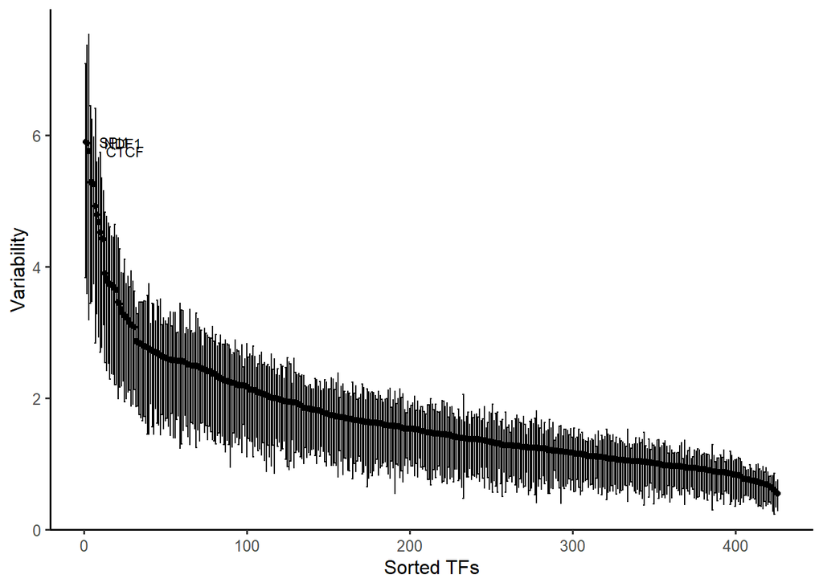

```r
variability <- computeVariability(dev)
plotVariability(variability)
```

```r
head(assays(dev)$z)
```

```
##      Control_female_GSM6041841.bam Control_female_GSM6041842.bam
## AHR                    -0.46092101                     0.2125217
## AIRE                    0.02167391                    -0.3758781
## ALX1                    0.66464567                     0.2314282
## ANDR                   -6.05647400                    -2.1081259
## AP2A                    0.35410925                    -1.9735660
## AP2B                    2.03154073                    -0.4640342
##      Control_female_GSM6041843.bam Control_male_GSM6041844.bam
## AHR                      0.3466043                  -0.3429793
## AIRE                    -2.4513661                   1.9393564
## ALX1                    -0.2847566                  -0.3808954
## ANDR                    -1.3528038                  -2.5845431
## AP2A                    -0.3559852                   2.0842974
## AP2B                    -1.1729096                   1.8085379
##      Control_male_GSM6041845.bam Control_male_GSM6041846.bam
## AHR                   0.61253009                 -0.63019275
## AIRE                  0.02780728                 -0.22162797
## ALX1                  0.43384991                 -1.29624211
## ANDR                 -3.48479471                 -4.69337847
## AP2A                  1.63552281                 -0.09578466
## AP2B                 -1.17901245                  0.62895650
##      FSS_female_GSM6041853.bam FSS_female_GSM6041854.bam
## AHR                  0.9083490                -0.2722145
## AIRE                 0.9232267                 1.3387138
## ALX1                -0.6325284                 0.8874033
## ANDR                 7.1783261                 0.2126627
## AP2A                 1.2801756                -1.7798299
## AP2B                 0.9086834                -0.3627080
##      FSS_female_GSM6041855.bam FSS_male_GSM6041856.bam FSS_male_GSM6041857.bam
## AHR                 -1.2159861              -0.9517575               0.6059025
## AIRE                 0.7422743               1.6801553               1.5103397
## ALX1                 0.1595828               0.7401437              -0.3413940
## ANDR                 6.3438924               4.6799919               6.4616356
## AP2A                 0.3853327               0.6977563               1.0944916
## AP2B                 0.2915783               1.5973298               0.9130699
##      FSS_male_GSM6041858.bam
## AHR              0.008459213
## AIRE             0.336870677
## ALX1            -0.320767041
## ANDR             4.550835162
## AP2A            -0.103615016
## AP2B            -0.557979642
```

```r
assays(dev)$norm <- scale(assays(dev)$z)
dev
```

```
## class: chromVARDeviations
## dim: 426 12
## metadata(0):
## assays(3): deviations z norm
## rownames(426): AHR AIRE ... ZN148 ZN423
## rowData names(3): name fractionMatches fractionBackgroundOverlap
## colnames(12): Control_female_GSM6041841.bam
##   Control_female_GSM6041842.bam ... FSS_male_GSM6041857.bam
##   FSS_male_GSM6041858.bam
## colData names(3): depth condition sex
```

#model

```r
mm <- model.matrix(~sex+condition, data=as.data.frame(colData(dev)))
mm
```

```
##                               (Intercept) sexMALE conditionFSS
## Control_female_GSM6041841.bam           1       0            0
## Control_female_GSM6041842.bam           1       0            0
## Control_female_GSM6041843.bam           1       0            0
## Control_male_GSM6041844.bam             1       1            0
## Control_male_GSM6041845.bam             1       1            0
## Control_male_GSM6041846.bam             1       1            0
## FSS_female_GSM6041853.bam               1       0            1
## FSS_female_GSM6041854.bam               1       0            1
## FSS_female_GSM6041855.bam               1       0            1
## FSS_male_GSM6041856.bam                 1       1            1
## FSS_male_GSM6041857.bam                 1       1            1
## FSS_male_GSM6041858.bam                 1       1            1
## attr(,"assign")
## [1] 0 1 2
## attr(,"contrasts")
## attr(,"contrasts")$sex
## [1] "contr.treatment"
##
## attr(,"contrasts")$condition
## [1] "contr.treatment"
```

```r
fit <- eBayes(lmFit(assays(dev)$norm, mm))

res <- as.data.frame(topTable(fit, coef="conditionFSS", number = Inf))
head(res)
```

```
##              logFC     AveExpr         t      P.Value   adj.P.Val         B
## ANDR     4.4492063  0.37616951  7.038199 5.413463e-06 0.002306135  4.104233
## GCR      2.9266862  0.34137261  5.992268 3.095791e-05 0.006594036  2.590242
## PRGR     1.9447199  0.04657794  3.353311 4.646734e-03 0.659836230 -1.955750
## MSX2     1.0800617  0.09828869  2.873215 1.212375e-02 0.994924203 -2.828939
## BHE41   -0.9049232 -0.25476900 -2.670655 1.809115e-02 0.994924203 -3.189834
## NR1I3.1  0.7978051  0.09539607  2.635855 1.937022e-02 0.994924203 -3.251132
```

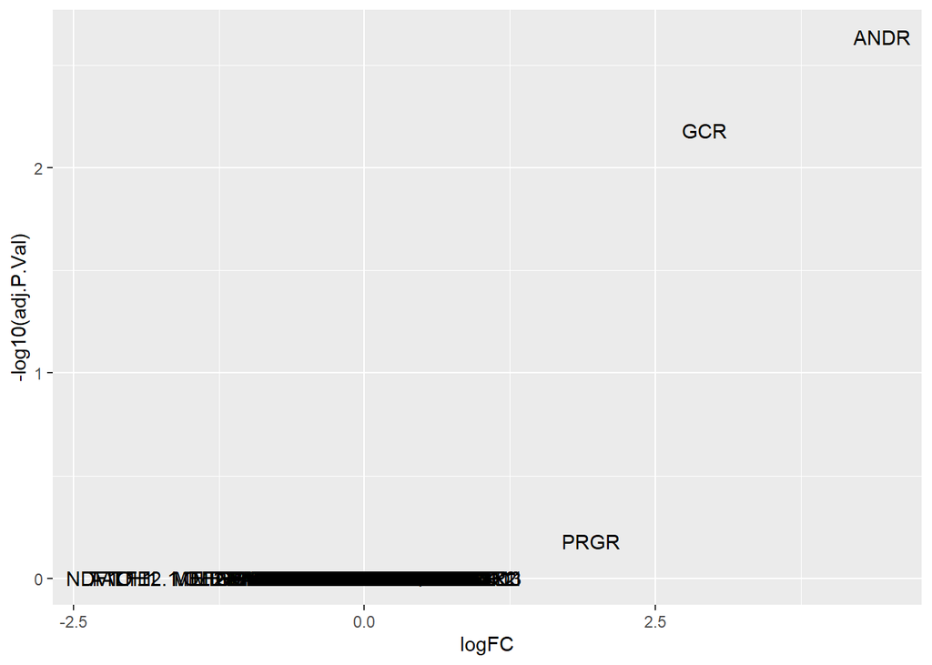

```r
res$TF <- row.names(res)
ggplot(res, aes(logFC, -log10(adj.P.Val), label=TF)) + geom_text()
```

The transcription factors with the greatest change in accessibility after FSS are ANDR (Androgen receptor) and GCR (Glucocorticoid receptor). The androgen receptor gets activated by binding testosterone, which is released during exercise. Thus it makes sense that the receptor is more active during forced swimming. The glucocorticoid response plays a crucial role in the “fight or flight” response and thus also makes sense in the context of forced swimming stress.

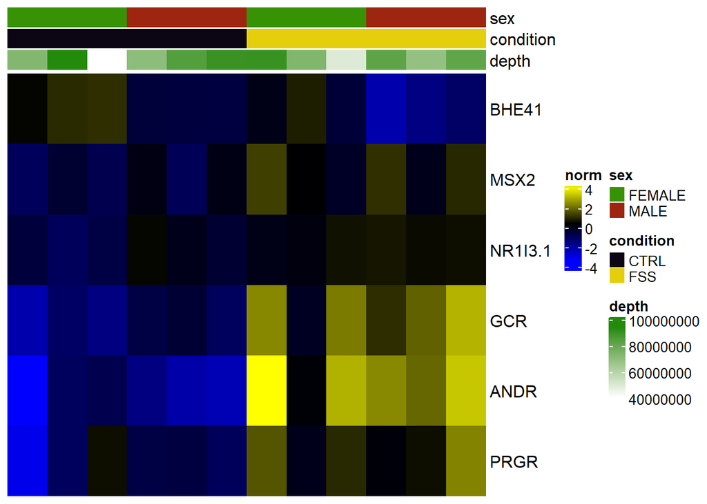

```r
sechm(dev, features = head(row.names(res)), assayName="norm", top_annotation = c("sex", "condition", "depth"))
```

Looking at the heatmap, we see that sex has very little effect on the expression of GCR and ANDR.

```r
res_sex <- as.data.frame(topTable(fit, coef="sexMALE", number = Inf))
head(res_sex)
```

```
##           logFC    AveExpr          t      P.Value    adj.P.Val        B
## TYY1  -5.435933 -0.2537557 -10.161418 6.670844e-08 0.0000263011 8.584828
## TEAD1 -4.379695 -0.1669351  -9.673987 1.234793e-07 0.0000263011 8.001325
## RUNX3 -2.339042 -0.1256998  -7.829548 1.594559e-06 0.0002264274 5.531835
## MYB   -2.369457 -0.2511062  -6.687467 9.553977e-06 0.0010174986 3.771430
## PTF1A -1.816082 -0.2079523  -5.640426 5.757511e-05 0.0049053994 1.989992
## ZN143 -2.251950  0.0781905  -5.300741 1.065022e-04 0.0075616531 1.378294
```

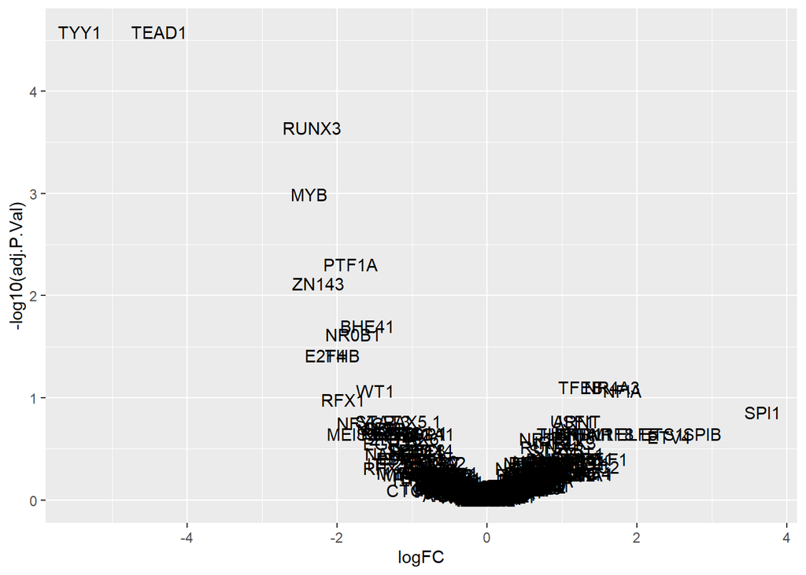

```r
res_sex$TF <- row.names(res_sex)
ggplot(res_sex, aes(logFC, -log10(adj.P.Val), label=TF)) + geom_text()
```

Comparing the signals of the difference sexes reveals that most of the differentially active TFs are less active in male mice. The strongest hits are TYY1 (Yin and Yang 1 protein) and TEAD1 (transcriptional enhancer factor 1). YY1 is important for X chromosome inactivation, thus it makes sense that it is predominantly active in females. I could not find any information why TEAD1 is more active in females than in males.

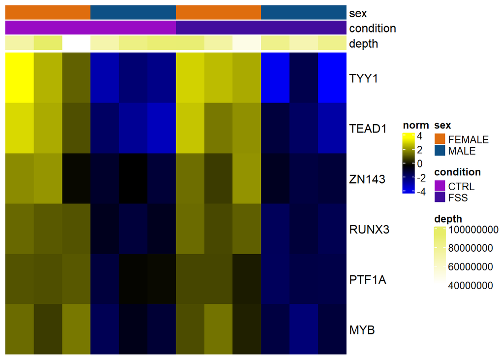

```r
sechm(dev, features = head(row.names(res_sex)), assayName="norm", top_annotation = c("sex", "condition", "depth"))
```

Looking at the heatmap, we see that at least for the strongest hits the condition has no effect on the activity of the sex-specific transcription factors.